# Analysis on COVID Spread in China and to Other Countries

Idioma, Salcedo, Taguiam

3/12/2020

## EDA - Part I: Analysis on COVID-19 Indicators

#### Importing the required libraries

```r
options(warn = -1)
library(tidyverse)
library(scales)
library(RColorBrewer)
library(ggthemes)
library(gridExtra)
library(ggrepel)
library(lubridate)
suppressPackageStartupMessages(library(DT))
suppressPackageStartupMessages(library(car))
suppressPackageStartupMessages(library(sf))
suppressPackageStartupMessages(library(sp))
suppressPackageStartupMessages(library(maps))
suppressPackageStartupMessages(library(rnaturalearth))
suppressPackageStartupMessages(library(rnaturalearthdata))
suppressPackageStartupMessages(library(spatstat))
suppressPackageStartupMessages(library(tidyverse))
suppressPackageStartupMessages(library(ggcorrplot))
suppressPackageStartupMessages(library(circlize))
```

#### Reading and Inspecting the data

```r
data <- read.csv("covid_19_data.csv")
data <- data[,c(1:2,4,6:8)]

data$isChina <- ifelse(data$Country %in% c("Mainland China", "China"),"China","Not China")

data$Date <- as.Date(data$ObservationDate, format = "%m/%d/%y")

data <- data[,-2]

head <- data[sample(1:nrow(data),5), ]
head <- head[order(head$SNo),]
head
```

```
##       SNo Country.Region Confirmed Deaths Recovered   isChina       Date
## 1117 1117         Sweden         1      0         0 Not China 2020-02-09
## 2877 2877    Netherlands        10      0         0 Not China 2020-03-01
## 3215 3215             US         1      0         0 Not China 2020-03-03
## 3248 3248 Mainland China       631      0       577     China 2020-03-04
## 5109 5109         France         2      0         0 Not China 2020-03-12
```

We are interested in 5 variables: date, number of infected, fatalities and cured in a given region, and whether the region under study belongs in China. The number of rows in the database increases with time. Due to the fact that we have only three quantitative variables, the analysis cannot be wide. The use of multivariate analysis methods doesn’t make sense because of the insufficient number of variables that are strongly related to each other, which can show incorrect regularities. The data encourage the analysis of time series, which will allow us to look at the studied phenomenon not only in a point-like manner.

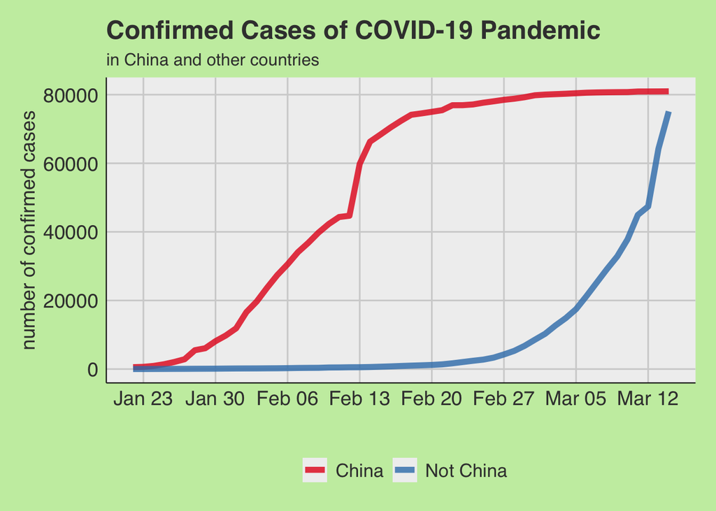

```r
Confirmed <- data %>%
  group_by(isChina, Date) %>%
  summarise(x = sum(Confirmed))

ggplot(Confirmed, aes(Date, x, colour = isChina))+
  geom_line(size = 2, alpha = 0.8)+
 # geom_point(size = 2.7)+
 # scale_y_continuous(trans="log10")+
  labs(x = "", y = "number of confirmed cases", title =  "Confirmed Cases of COVID-19 Pandemic", subtitle = "in China and other countries")+
# geom_text_repel(aes(label = x), nudge_y = 1100, color = "black", size = 3.9)+
  scale_x_date(date_labels = "%b %d", date_breaks = "7 days")+
  scale_colour_brewer(palette = "Set1")+
  theme_fivethirtyeight()+
  theme(legend.position="bottom", legend.direction="horizontal", legend.title = element_blank(), axis.text = element_text(size = 14),
        legend.text = element_text(size = 13), axis.title = element_text(size = 14), axis.line = element_line(size = 0.4, colour = "grey10"),
        plot.background = element_rect(fill = "#C8EDAF"), legend.background = element_rect(fill = "#C8EDAF"))
```

We study and compare the number of people infected within China and to the other countries. The number of confirmed cases in China is very high and escalating in fast pace with at almost 17 times in a week compared to the number of confirmed cases in other countries. One factor of the sudden increase, however, is the delay of data or confirmation.

In other countries outside China, we can also observe an upward trend of number of confirmed cases, similar to that in China, from the last week of February. Several factors can be observed in this behavior:

1. The 14-day incubation period of COVID-19 is more than enough time for an infected person to spread the virus since he or she is a carrier from day 1.
2. Lack of accessibility for testing
3. Population density
4. Median Age as older people are more susceptible to the disease<sup>1</sup>

<sup>1</sup> https://www.worldometers.info/coronavirus/coronavirus-age-sex-demographics/

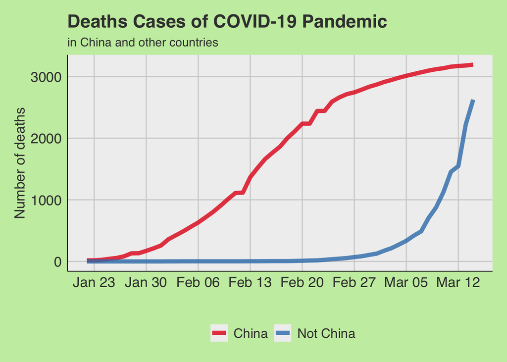

```r
Death <- data %>%
  group_by(isChina, Date) %>%
  summarise(x = sum(Deaths))

ggplot(Death, aes(Date, x, colour = isChina))+
  geom_line(size = 2, alpha = 0.8)+
 #geom_point(size = 2.7)+
 #scale_y_continuous(trans="log10")+
  scale_x_date(date_labels = "%b %d", date_breaks = "7 days")+
  labs(x = "", y = "Number of deaths", title =  "Deaths Cases of COVID-19 Pandemic", subtitle = "in China and other countries")+
 #geom_text_repel(aes(label = x), nudge_y = 40, color = "black", size = 4.1)+
  scale_colour_brewer(palette = "Set1")+
  theme_fivethirtyeight()+
  theme(legend.position="bottom", legend.direction="horizontal", legend.title = element_blank(), axis.text = element_text(size = 14),
        legend.text = element_text(size = 13), axis.title = element_text(size = 14), axis.line = element_line(size = 0.4, colour = "grey10"),
        plot.background = element_rect(fill = "#C8EDAF"), legend.background = element_rect(fill = "#C8EDAF"))
```

So while China has already developed containment measures, other countries have just started to do the same. It is all in a matter of time.

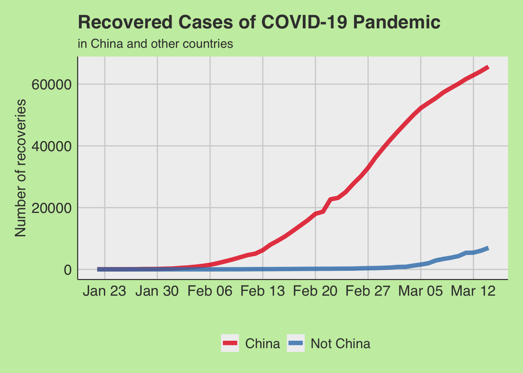

```r
Recovered <- data %>%
  group_by(isChina, Date) %>%
  summarise(x = sum(Recovered))

ggplot(Recovered, aes(Date, x, colour = isChina))+
  geom_line(size = 2, alpha = 0.8)+
  #geom_point(size = 2.7)+
  #scale_y_continuous(trans="log10")+
  scale_x_date(date_labels = "%b %d", date_breaks = "7 days")+
  labs(x = "", y = "Number of recoveries", title =  "Recovered Cases of COVID-19 Pandemic", subtitle = "in China and other countries")+
 # geom_text_repel(aes(label = x), nudge_y = 95, color = "black", size = 3.9)+
  scale_colour_brewer(palette = "Set1")+
  theme_fivethirtyeight()+
  theme(legend.position="bottom", legend.direction="horizontal", legend.title = element_blank(), axis.text = element_text(size = 14),
        legend.text = element_text(size = 13), axis.title = element_text(size = 14), axis.line = element_line(size = 0.4, colour = "grey10"),
        plot.background = element_rect(fill = "#C8EDAF"), legend.background = element_rect(fill = "#C8EDAF"))
```

Here we are looking at the trend of the recovered cases of COVID-19 Pandemic. The information is very positive when it comes to China, because the growth rate of cured people is higher than deaths. In the middle of February, there are about 1,000 cured per day on average. The rest of the countries are also fighting back - while there were no fatalities by the end of January, ten people outside China were already been cured. Taking into account the situation from China, it seems that the number of recovered patients may start to increase at a much faster rate.

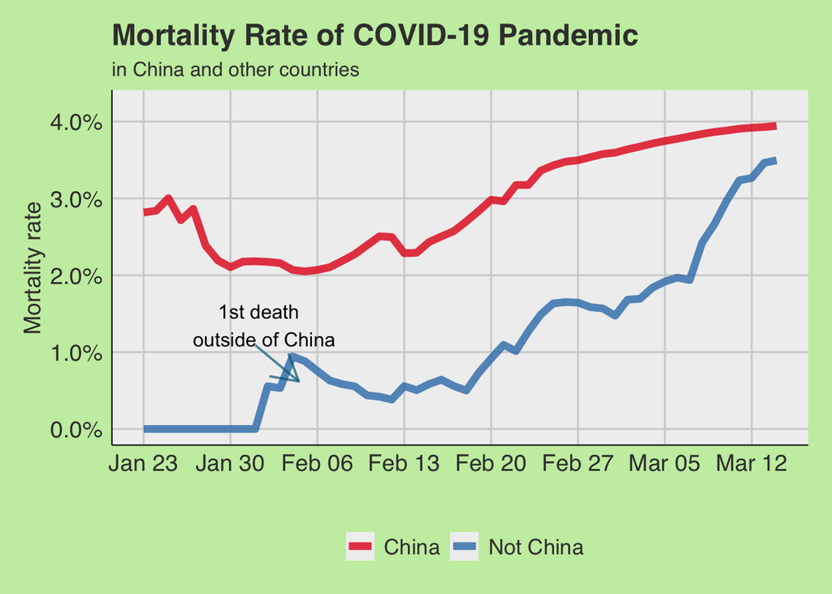

```r
Tog2 <- cbind(Death, Confirmed)
Tog2 <- Tog2[,c(1,2,3,6)]
names(Tog2)[3:4] <- c("Deaths", "Total")
Tog2$Dea2All <- Tog2$Deaths/Tog2$Total
Tog2 <- Tog2[Tog2$Date>"2020-01-22", ]
#Tog2_China <- Tog2[1:14,]
ggplot(Tog2, aes(Date,Dea2All, colour = isChina))+
  geom_line(size = 2.2, alpha = 0.8)+
  #geom_point(size = 3)+
  labs(x = "", y = "Mortality rate", title =  "Mortality Rate of COVID-19 Pandemic", subtitle = "in China and other countries", colour = "")+
  #geom_text_repel(aes(label = paste0(round(100*Dea2All,1), "%")), nudge_y = 0.0013, nudge_x = 0.2, color = "black", size = 3.8)+
  scale_y_continuous(labels = scales::percent, limits = c(0,0.042))+
  scale_x_date(date_labels = "%b %d", date_breaks = "7 days")+
  scale_colour_brewer(palette = "Set1")+
  theme_fivethirtyeight()+
  annotate("text", x = mean(Tog2$Date)-16, y = 0.0135, label = "1st death \n outside of China", size = 4.2)+
  annotate("segment", x = mean(Tog2$Date)-16.5, xend = mean(Tog2$Date)-13, y = 0.0109, yend = 0.0062, colour = "deepskyblue4", size=0.7, alpha=0.7, arrow=arrow())+
  theme(legend.position="bottom", legend.direction="horizontal", axis.text = element_text(size = 14), axis.title = element_text(size = 14),
        legend.text = element_text(size = 13), axis.line = element_line(size = 0.4, colour = "grey10"),
        plot.background = element_rect(fill = "#C8EDAF"), legend.background = element_rect(fill = "#C8EDAF"))
```

Here we are going to start to calculate the indicators to show the whole specifics of the COVID-19 Pandemic as absolute information is not enough. Mortality rate is one indicator that shows the ratio of people who died, due to the virus, to all infected. Throughout the history of the virus to date, this ratio is between 2% and 4% in China. From January 31, we can compare the ratio to the other countries because then, the first fatality was recorded outside of China. Initially, the mortality rate increased, but it began to decrease over time and never exceeded 1% until February 20. After that, mortality rate continued to increase exponentially up to 2.7% as of March 10 due to the start of the outbreak in Italy, Korea, and Iran. It is worth bearing in mind that the victims are usually an elderly person or with other diseases, so this value cannot be treated as the probability of death of a newly infected person.

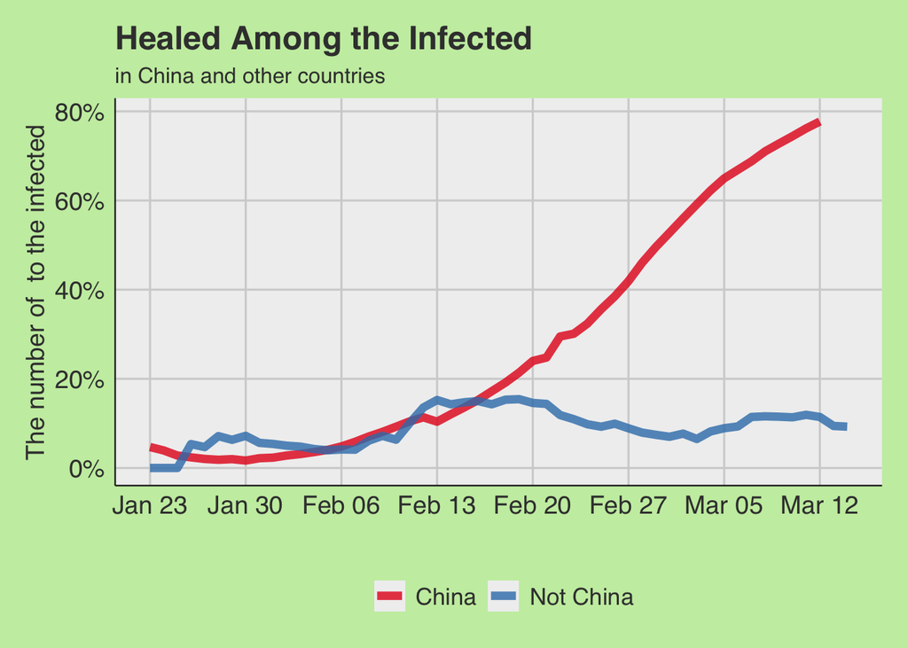

```r
Tog3 <- cbind(Recovered, Confirmed)
Tog3 <- Tog3[,c(1,2,3,6)]
names(Tog3)[3:4] <- c("Recovered", "Total")
Tog3$Rec2All <- Tog3$Recovered/Tog3$Total
Tog3 <- Tog3[Tog3$Date>"2020-01-22", ]
ggplot(Tog3, aes(Date,Rec2All, colour = isChina))+
  geom_line(size = 2.2, alpha = 0.8)+
  #geom_point(size = 3)+
  labs(x = "", y = "The number of  to the infected", title =  "Healed Among the Infected", subtitle = "in China and other countries", colour = "")+
  #geom_text(aes(label = paste0(round(100*Rec2All,1), "%")), nudge_y = 0.0025, nudge_x = 0.2, color = "black", size = 4.1)+
  scale_y_continuous(labels = scales::percent, limits = c(0,0.79))+
  scale_x_date(date_labels = "%b %d", date_breaks = "7 days")+
  scale_colour_brewer(palette = "Set1")+
  theme_fivethirtyeight()+
  theme(legend.position="bottom", legend.direction="horizontal", axis.text = element_text(size = 14), axis.title = element_text(size = 14), legend.text = element_text(size = 13),
        axis.line = element_line(size = 0.4, colour = "grey10"), plot.background = element_rect(fill = "#C8EDAF"), legend.background = element_rect(fill = "#C8EDAF"))
```

The graph shows the percentage of people completely recovered off the virus. Initially, the value of this coefficient in China was high, but it decreased over time to reach its bottom on 27 January. Since then, we have seen a moderate increase in what should be considered positive, an increase from 2% to even 75% is optimistic. Outside of China, the coefficient value behaves more irregularly - so more time is needed to draw conclusions, but there are indications that the participation of such people will start to increase as in China.

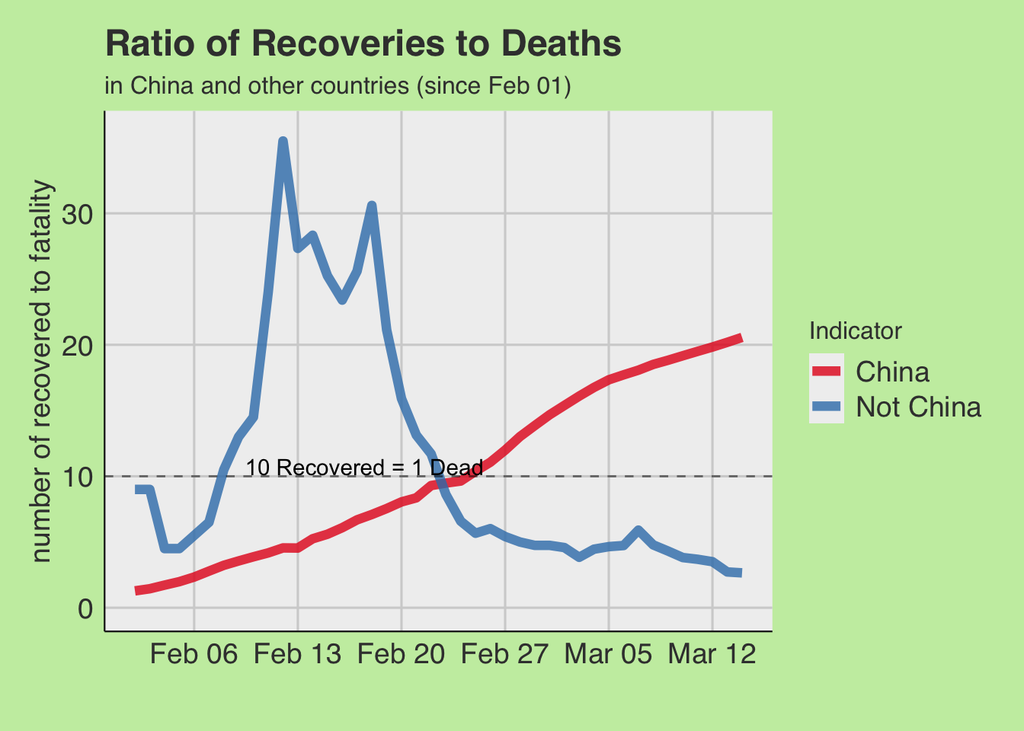

```r
Tog <- cbind(Death, Recovered)
Tog <- Tog[,c(1,2,3,6)]
names(Tog)[3:4] <- c("Deaths", "Recovered")
Tog$Recovered2Death <- Tog$Recovered/Tog$Deaths
Tog <- Tog[Tog$Date>"2020-02-01", ]
ggplot(Tog, aes(Date, Recovered2Death, colour = isChina))+
  geom_line(size = 2.2, alpha = 0.8)+
  #geom_point(size = 3.3)+
  labs(x = "", y = "number of recovered to fatality", title =  "Ratio of Recoveries to Deaths", subtitle = "in China and other countries (since Feb 01)", colour = "Indicator")+
  #geom_text_repel(aes(label = round(Rec2Dea,1)), nudge_y = 0.115, color = "black", size = 4.5)+
  scale_colour_brewer(palette = "Set1")+
  scale_y_continuous(limits = c(0,36))+
  scale_x_date(date_labels = "%b %d", date_breaks = "7 days")+
  geom_hline(yintercept = 10, linetype = 2, alpha = 0.5)+
  annotate("text", x = mean(Tog$Date)-5, y = 10.7, label = "10 Recovered = 1 Dead", size = 3.9)+
  theme_fivethirtyeight()+
  theme(legend.position="right", legend.direction="vertical", axis.text = element_text(size = 14), axis.title = element_text(size = 14),
        legend.text = element_text(size = 14), axis.line = element_line(size = 0.4, colour = "grey10"),
        plot.background = element_rect(fill = "#C8EDAF"), legend.background = element_rect(fill = "#C8EDAF"))
```

At the end of this exploratory analysis, we look at the ratio of the number of healed people to the dead. Values above 1 mean the advantage of the cured people over the dead. Due to the small number of observations in the first days, we decide to start counting this indicator from February 1. In China, we are observing a steady increase in value, while outside of this country we are observing “sharp jumps”, so like the previous chart, we find that it takes time to draw compact conclusions.

## EDA - Part II: Evolution Analysis of COVID-19

In the first part, we were able to compare the indicators between China and other countries. Now, let us examine the aggregated features and rank the spread of the virus per country.

#### 2.1. Inspect the dataframe using an interactive data table feature

```r
PRINT_MODE = 'datatable'
print_df <- function(df_in) {
  if (PRINT_MODE == 'datatable') {
    return(datatable(df_in))
  }
  return(df_in)
}

df_covid <- read_csv(str_c('covid_19_data.csv'))
colnames(df_covid) <- make.names(colnames(df_covid))
df_covid %>% print_df()
```

|  | SNo | ObservationDate | Province.State | Country.Region | Last.Update | Confirmed | Deaths | Recovered |
| --- | --- | --- | --- | --- | --- | --- | --- | --- |
| 1 | 1 | 01/22/2020 | Anhui | Mainland China | 1/22/2020 17:00 | 1 | 0 | 0 |
| 2 | 2 | 01/22/2020 | Beijing | Mainland China | 1/22/2020 17:00 | 14 | 0 | 0 |
| 3 | 3 | 01/22/2020 | Chongqing | Mainland China | 1/22/2020 17:00 | 6 | 0 | 0 |
| 4 | 4 | 01/22/2020 | Fujian | Mainland China | 1/22/2020 17:00 | 1 | 0 | 0 |
| 5 | 5 | 01/22/2020 | Gansu | Mainland China | 1/22/2020 17:00 | 0 | 0 | 0 |
| 6 | 6 | 01/22/2020 | Guangdong | Mainland China | 1/22/2020 17:00 | 26 | 0 | 0 |
| 7 | 7 | 01/22/2020 | Guangxi | Mainland China | 1/22/2020 17:00 | 2 | 0 | 0 |
| 8 | 8 | 01/22/2020 | Guizhou | Mainland China | 1/22/2020 17:00 | 1 | 0 | 0 |
| 9 | 9 | 01/22/2020 | Hainan | Mainland China | 1/22/2020 17:00 | 4 | 0 | 0 |
| 10 | 10 | 01/22/2020 | Hebei | Mainland China | 1/22/2020 17:00 | 1 | 0 | 0 |

[output cut: 5622 more lines]

In the next sections, we will take different insights by studying the evolution of the COVID19 in different perspectives of view, following a top-bottom approach. So, we will start from the most aggregated features before understanting the specific variables.

#### 2.2. Visualization of Aggregated Indicators

```r
correct_year <- function(date_in) {
    if (nchar(str_split(date_in, "/")[[1]][[3]]) == 2) {
        return(str_c(date_in, '20'))
    }
    date_in
}

df_covid$ObservationDate <- sapply(df_covid$ObservationDate, correct_year)

df_covid <- df_covid %>%
    mutate(ObservationDate = as.Date(ObservationDate, '%m/%d/%Y'))

df_covid_time_aggregate <- df_covid %>%
  group_by(ObservationDate) %>%
  summarise_at(vars(Confirmed, Deaths, Recovered), sum) %>%
  pivot_longer(cols = c('Confirmed', 'Deaths', 'Recovered'),
               names_to = 'Feature', values_to = 'Value')

df_covid_time_aggregate %>% print_df()
```

|  | ObservationDate | Feature | Value |
| --- | --- | --- | --- |
| 1 | 2020-01-22 | Confirmed | 555 |
| 2 | 2020-01-22 | Deaths | 17 |
| 3 | 2020-01-22 | Recovered | 28 |
| 4 | 2020-01-23 | Confirmed | 653 |
| 5 | 2020-01-23 | Deaths | 18 |
| 6 | 2020-01-23 | Recovered | 30 |
| 7 | 2020-01-24 | Confirmed | 941 |
| 8 | 2020-01-24 | Deaths | 26 |
| 9 | 2020-01-24 | Recovered | 36 |
| 10 | 2020-01-25 | Confirmed | 1438 |

[output cut: 149 more lines]

The long form shows all different values in the same column aggregated by countries and regions. The kind of value will be determined in the ???Feature??? column, which works as a ???metadata??? feature of the table.

Now we plot the aggregated variables:

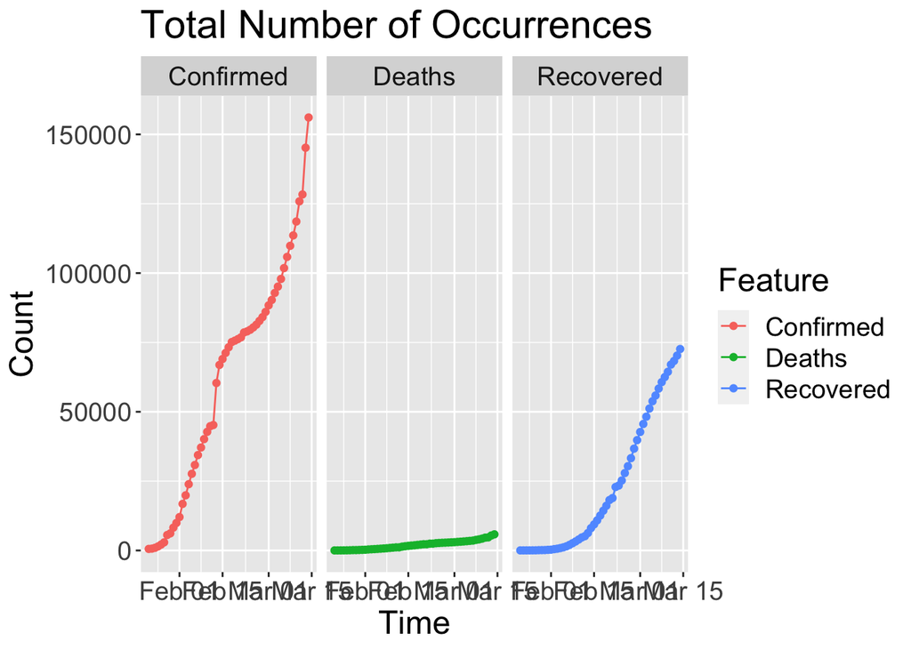

```r
ggplot(df_covid_time_aggregate,
       aes(x = ObservationDate, y = Value,
           group = Feature, fill = Feature, colour = Feature)) +
  geom_line() + geom_point() + facet_wrap(Feature~.) +
  theme(text = element_text(size = 18)) + xlab('Time') + ylab('Count') +
  ggtitle('Total Number of Occurrences')
```

#### 2.3. COVID-19 Rank per Country

We will rank the countries by the places where the most recent number of confirmed cases are larger. We will append the ranking numbers before the names of the countries:

```r
df_covid_max_count <- df_covid %>%
  group_by(Country.Region) %>%
  summarise_at(vars(Confirmed, Deaths, Recovered), max) %>%
  arrange(desc(Confirmed))

df_covid_max_count$Ranking <- str_pad(as.character(1:nrow(df_covid_max_count)), 2, pad = '0')
df_covid_max_count$Prefix <- ' - '
df_covid_max_count <- df_covid_max_count %>%
  mutate(Ranked.Country = str_c(Ranking, Prefix, Country.Region)) %>%
  mutate(Ranking = Ranking)
df_covid_max_count %>% print_df()
```

|  | Country.Region | Confirmed | Deaths | Recovered | Ranking | Prefix | Ranked.Country |
| --- | --- | --- | --- | --- | --- | --- | --- |
| 1 | Mainland China | 67790 | 3075 | 52960 | 01 | - | 01 - Mainland China |
| 2 | Italy | 21157 | 1441 | 1966 | 02 | - | 02 - Italy |
| 3 | Iran | 12729 | 611 | 2959 | 03 | - | 03 - Iran |
| 4 | South Korea | 8086 | 72 | 510 | 04 | - | 04 - South Korea |
| 5 | Spain | 6391 | 195 | 517 | 05 | - | 05 - Spain |
| 6 | Germany | 4585 | 9 | 46 | 06 | - | 06 - Germany |
| 7 | France | 4469 | 91 | 12 | 07 | - | 07 - France |
| 8 | Switzerland | 1359 | 13 | 4 | 08 | - | 08 - Switzerland |
| 9 | UK | 1140 | 21 | 18 | 09 | - | 09 - UK |
| 10 | Norway | 1090 | 3 | 1 | 10 | - | 10 - Norway |

[output cut: 145 more lines]

```r
df_rank_countries <- df_covid_max_count %>% select(Country.Region, Ranking, Ranked.Country)
df_rank_countries$ObservationDate <- NULL

df_covid_countries_evolution <- df_covid %>%
  group_by(ObservationDate, Country.Region) %>%
  summarise_at(vars(Confirmed, Deaths, Recovered), sum) %>%
  inner_join(df_rank_countries, by = c('Country.Region' = 'Country.Region'))
```

Outside China, the countries Italy, South Korea, and Iran are the top countries with high confirmed cases.

Cases have spread across Italy???s north and down to Rome, leading to a lockdown of the entire country. Iran???s capital, where leaders dismissed the virus just two weeks ago, has seen thousands infected. And cases continue to surge across Europe.

With more than 15,000 confirmed cases, Italy has reported the largest outbreak outside of China. Italian authorities first put restrictions in place in the northern region of Lombardy, where the outbreak first accelerated, before moving on Monday to restrict the movement and end public gatherings for all 60 million citizens in the country. At least 1,000 people have died because of the virus.

In Iran, two weeks ago, Iran???s leaders denied the coronavirus epidemic would be a problem. Now, with the total number of cases standing at more than 10,000, and with more than 400 people dead, Iran is scrambling to control one of the worst outbreaks in the world. The authorities failed to take protective measures at this early stage. But the problem became impossible to ignore after nearly three dozen Iranian government officials and members of parliament were infected, and a senior adviser to the supreme leader died.

The outbreaks are not all heading in the same direction. South Korea has managed to slow growth of new cases for now, through intensive testing and monitoring of infections. Italy, Iran and the United States are still reporting large numbers of new cases every day.

#### 2.4. Mortality Rate per Country and Bernoulli Hypothesis Tests

In this section, we will use the information we have to estimate the probability of fatality after getting infected with its respective standard deviation for each country and for all the world.

This can be visually represented in a plot with error bars:

```r
df_covid
```

```
## # A tibble: 5,632 x 8
##      SNo ObservationDate Province.State Country.Region Last.Update
##    <dbl> <date>          <chr>          <chr>          <chr>
##  1     1 2020-01-22      Anhui          Mainland China 1/22/2020 ~
##  2     2 2020-01-22      Beijing        Mainland China 1/22/2020 ~
##  3     3 2020-01-22      Chongqing      Mainland China 1/22/2020 ~
##  4     4 2020-01-22      Fujian         Mainland China 1/22/2020 ~
##  5     5 2020-01-22      Gansu          Mainland China 1/22/2020 ~
##  6     6 2020-01-22      Guangdong      Mainland China 1/22/2020 ~
##  7     7 2020-01-22      Guangxi        Mainland China 1/22/2020 ~
##  8     8 2020-01-22      Guizhou        Mainland China 1/22/2020 ~
##  9     9 2020-01-22      Hainan         Mainland China 1/22/2020 ~
## 10    10 2020-01-22      Hebei          Mainland China 1/22/2020 ~
## # ... with 5,622 more rows, and 3 more variables: Confirmed <dbl>,
## #   Deaths <dbl>, Recovered <dbl>
```

```r
last_date <- max(df_covid$ObservationDate)
df_covid_last <- df_covid %>%
  filter(ObservationDate == last_date) %>%
  group_by(Country.Region) %>%
  summarise_at(vars('Confirmed', 'Deaths', 'Recovered'), sum) %>%
  filter(Deaths > 0) %>%
  mutate(Mortality = Deaths / Confirmed) %>%
  mutate(Std = sqrt((Mortality * (1 - Mortality)) / sqrt(Confirmed)))

df_covid_last %>% print_df()
```

|  | Country.Region | Confirmed | Deaths | Recovered | Mortality | Std |
| --- | --- | --- | --- | --- | --- | --- |
| 1 | Albania | 38 | 1 | 0 | 0.0263157894736842 | 0.0644720331788507 |
| 2 | Algeria | 37 | 3 | 12 | 0.0810810810810811 | 0.110674592296273 |
| 3 | Argentina | 34 | 2 | 1 | 0.0588235294117647 | 0.0974409121333064 |
| 4 | Australia | 250 | 3 | 23 | 0.012 | 0.0273831933634324 |
| 5 | Austria | 655 | 1 | 6 | 0.00152671755725191 | 0.00771768856222526 |
| 6 | Azerbaijan | 15 | 1 | 3 | 0.0666666666666667 | 0.126750576706297 |
| 7 | Belgium | 689 | 4 | 1 | 0.0058055152394775 | 0.0148286376861819 |
| 8 | Bulgaria | 41 | 2 | 0 | 0.0487804878048781 | 0.0851270297852932 |
| 9 | Canada | 196 | 1 | 8 | 0.00510204081632653 | 0.0190413272268413 |
| 10 | Denmark | 836 | 1 | 1 | 0.00119617224880383 | 0.00642814094943534 |

[output cut: 35 more lines]

Shown above is an interactive dataframe of countries with COVID cases and their corresponding mortality rates.

We have approximately $95 \%$ of probability inside a centered interval with a width of $\pm 2$ standard deviations:

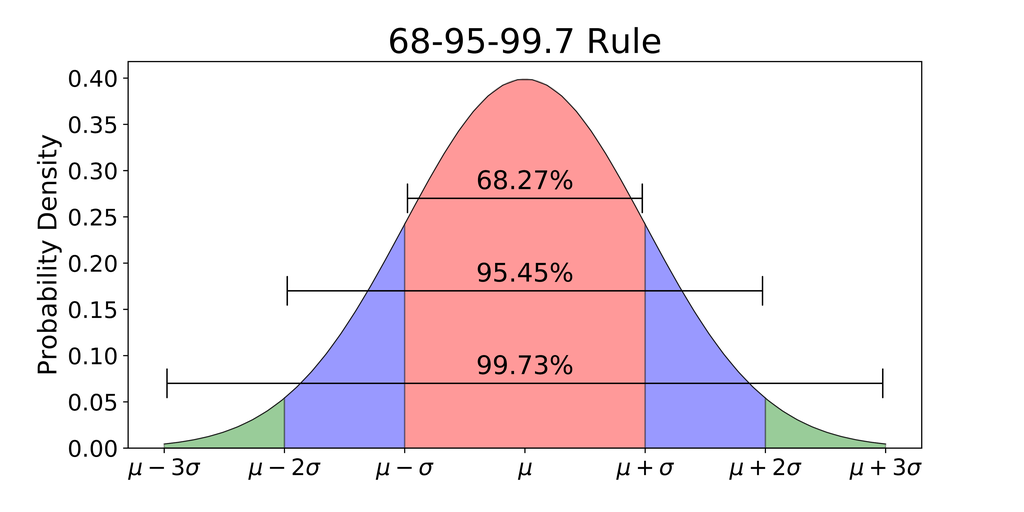

Intervals - Gaussian

[figure not shown]

```r
df_covid_last_filtered <- df_covid_last %>% filter(Confirmed > 100)
mean_mortality <- sum(df_covid_last_filtered$Deaths) / sum(df_covid_last_filtered$Confirmed)

ggplot(df_covid_last_filtered,
       aes(x = reorder(Country.Region, Mortality), fill = Country.Region)) +
  geom_hline(yintercept = mean_mortality, linetype = 'dashed', color = 'red') +
  geom_errorbar(aes(ymin = Mortality - 2 * Std, ymax = Mortality + 2 * Std)) +
  geom_point(aes(y = Mortality), size = 10, color = 'black', shape=21) +
  theme(text = element_text(size = 18), legend.position = 'none') +
  xlab('Country') + coord_flip() +
  ggtitle('Mortality Rate') + labs(subtitle = 'Hypothesis Test at 90% of Significance')
```

The South Korea is the fourth country in the infections number ranking and has a smaller mortality rate. It???s interesting and maybe it???s an indication of an excellent health care system or something related to the average age of the population.

```r
mean_mortality
```

```
## [1] 0.03811977
```